# Assigment 1b

Zulikah Latief (s4273281)

30/11/2021

```r
rm(list=ls())
#load data
load("data_herlambang.rda")
```

## Q1a

**How many participants are included in the data? How many trials and blocks did each participant do?**

There are 20 subjects in the data. Each of them took part in 672 trails which were divided into 14 blocks (48 trails per block). All participants took part in the 14 blocks.

```r
summary(dat)
```

```
##     subject          trial           block           ans             ans1
##  Min.   : 1.00   Min.   :  1.0   Min.   : 1.0   Min.   :33.00   Min.   :3.000
##  1st Qu.: 5.75   1st Qu.:168.8   1st Qu.: 4.0   1st Qu.:47.00   1st Qu.:4.000
##  Median :10.50   Median :336.5   Median : 7.5   Median :56.00   Median :5.000
##  Mean   :10.50   Mean   :336.5   Mean   : 7.5   Mean   :57.74   Mean   :5.251
##  3rd Qu.:15.25   3rd Qu.:504.2   3rd Qu.:11.0   3rd Qu.:65.00   3rd Qu.:6.000
##  Max.   :20.00   Max.   :672.0   Max.   :14.0   Max.   :95.00   Max.   :9.000
##       ans2        compensation        condition       correct
##  Min.   :3.000   Min.   : 0.000   no_reward:6720   Min.   :0.0000
##  1st Qu.:4.000   1st Qu.: 1.000   reward   :6720   1st Qu.:0.0000
##  Median :5.000   Median : 2.375                    Median :0.0000
##  Mean   :5.238   Mean   : 2.820                    Mean   :0.3809
##  3rd Qu.:6.000   3rd Qu.: 4.275                    3rd Qu.:1.0000
##  Max.   :9.000   Max.   :11.350                    Max.   :1.0000
##     correct2            fast          resp_ans     response_space
##  Min.   :-1.0000   Min.   :0.000   Min.   : 0.00   None :6028
##  1st Qu.:-1.0000   1st Qu.:0.000   1st Qu.:45.00   space:7412
##  Median :-1.0000   Median :0.000   Median :55.00
##  Mean   :-0.2382   Mean   :0.374   Mean   :48.61
##  3rd Qu.: 1.0000   3rd Qu.:1.000   3rd Qu.:64.00
##  Max.   : 1.0000   Max.   :1.000   Max.   :99.00
##  response_time_space     waktu1
##  Min.   :   3        Min.   :2200
##  1st Qu.:3200        1st Qu.:4500
##  Median :4102        Median :4900
##  Mean   :3941        Mean   :4670
##  3rd Qu.:4900        3rd Qu.:5000
##  Max.   :5122        Max.   :5100
```

```r
#Subjects by block
head(table(dat$subject, dat$block))
```

```
##
##      1  2  3  4  5  6  7  8  9 10 11 12 13 14
##   1 48 48 48 48 48 48 48 48 48 48 48 48 48 48
##   2 48 48 48 48 48 48 48 48 48 48 48 48 48 48
##   3 48 48 48 48 48 48 48 48 48 48 48 48 48 48
##   4 48 48 48 48 48 48 48 48 48 48 48 48 48 48
##   5 48 48 48 48 48 48 48 48 48 48 48 48 48 48
##   6 48 48 48 48 48 48 48 48 48 48 48 48 48 48
```

**The column condition marks whether the participant received a reward in this block or not. In which blocks were rewards given? Did all participants receive a reward in the same block?**

Rewards were given in alternating blocks. Blocks 2,4,6,8,10,12,14 were reward blocks. All participants received rewards only in the aforementioned reward blocks.

```r
#Blocks by subject
head(table(dat$condition, dat$block))
```

```
##
##               1   2   3   4   5   6   7   8   9  10  11  12  13  14
##   no_reward 960   0 960   0 960   0 960   0 960   0 960   0 960   0
##   reward      0 960   0 960   0 960   0 960   0 960   0 960   0 960
```

```r
head(table(dat$subject, dat$condition, dat$block))
```

```
## , ,  = 1
##
##
##     no_reward reward
##   1        48      0
##   2        48      0
##   3        48      0
##   4        48      0
##   5        48      0
##   6        48      0
##
## , ,  = 2
##
##
##     no_reward reward
##   1         0     48
##   2         0     48
##   3         0     48
##   4         0     48
##   5         0     48
##   6         0     48
##
## , ,  = 3
##
##
##     no_reward reward
##   1        48      0
##   2        48      0
##   3        48      0
##   4        48      0
##   5        48      0
##   6        48      0
##
## , ,  = 4
##
##
##     no_reward reward
##   1         0     48
##   2         0     48
##   3         0     48
```

[output cut: 98 more lines]

```
##   3        48      0
##   4        48      0
##   5        48      0
##   6        48      0
##
## , ,  = 14
##
##
##     no_reward reward
##   1         0     48
##   2         0     48
##   3         0     48
##   4         0     48
##   5         0     48
##   6         0     48
```

## Q1b

**Inspect the plot. Describe the effect of condition and block on the proportion of space bar being pressed.**

The plot shows the average proportion of the space bars being pressed in relation with the condition of each block. First, it is evident that the average proportion of space bar pressed in the non-reward condition is lower than the corresponding reward block. It can also be observed that for the non-reward blocks there is a gradual increase in the proportion of the space-bar pressed as the blocks progress. However, for the reward block, slight fluctuations (increase and then decrease, vice-versa) in the proportion of space bar pressed can be observed.

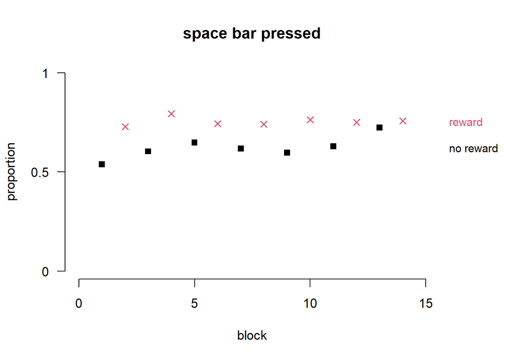

```r
#install.packages('ddply')
#library(ddply)
library(plyr)
dat.cor <- droplevels(dat[dat$correct > 0,])

avg <- ddply(dat.cor, c("block", "condition"),
             summarise,
             space=mean(response_space=="space", na.rm=FALSE))

library(plotfunctions)

# increase labels and left margin:
par(cex=1.1, mar=c(5.1,4.1,4.1,4.1))
# setup empty plot with simplified axes:
emptyPlot(c(0,15), c(0,1), # x-range, y-range plot
          main="space bar pressed", # title
          xlab="block", ylab="proportion", # labels axes
          ymark=c(0,.5,1), las=1) # simplify y-axis

# add averages:
points(avg$block, avg$space, lwd=1.5,
       pch=ifelse(avg$condition=="no_reward", 15,4),
       bg='white',
       col=ifelse(avg$condition=="no_reward", 1,2 ))

# add legend:
leg <- tapply(avg$space, list(avg$condition), mean)
text(c(16,16), leg,  labels=gsub("_", " ", names(leg)),
     adj=0, col=ifelse(names(leg)=="no_reward", 1,2), cex=.85, xpd=TRUE)
```

## Q1c

**Calculate the mean response latency per block, condition, and response_space (only for the responses that are (partly) correct, so using data dat.cor).** The mean response latency per block is:

```r
#avg latency per block
avg_latency_block<- ddply(dat.cor, c("block"),
             summarise,
            latency = mean(response_time_space))
head(avg_latency_block)
```

```
##   block  latency
## 1     1 4059.850
## 2     2 3705.869
## 3     3 4105.887
## 4     4 3531.571
## 5     5 3897.846
## 6     6 3649.133
```

The mean response latency per condition is:

```r
#split dataset based on conditions
reward.dat <- subset(dat.cor, condition == "reward")
no_reward.dat <- subset(dat.cor, condition == "no_reward")

#avg latency for reward condition
avg_latency_rew<- ddply(reward.dat, c("condition"),
             summarise,
            latency = mean(response_time_space))
avg_latency_rew
```

```
##   condition  latency
## 1    reward 3567.783
```

```r
#avg latency for no_reward condition
avg_latency_no_rew<- ddply(no_reward.dat, c("condition"),
             summarise,
            latency = mean(response_time_space))
avg_latency_no_rew
```

```
##   condition  latency
## 1 no_reward 3927.516
```

The mean response latency based on response_space is:

```r
#avg latency per response_space
avg_latency_resp_space<- ddply(dat.cor, c("response_space"),
             summarise,
            latency = mean(response_time_space))
head(avg_latency_resp_space)
```

```
##   response_space  latency
## 1           None 4608.544
## 2          space 3335.982
```

The mean response latency per condition per response_space is:

```r
#avg latency for reward condition with response space
avg_latency_rew_resp_space<- ddply(reward.dat, c("condition", "response_space"),
             summarise,
            latency = mean(response_time_space))

#avg latency for no_reward condition with response space
avg_latency_no_rew_resp_space<- ddply(no_reward.dat, c("condition", "response_space"),
             summarise,
            latency = mean(response_time_space))
```

**Visualize how the response latencies change per condition, per block, and per response condition (i.e., response_space).**

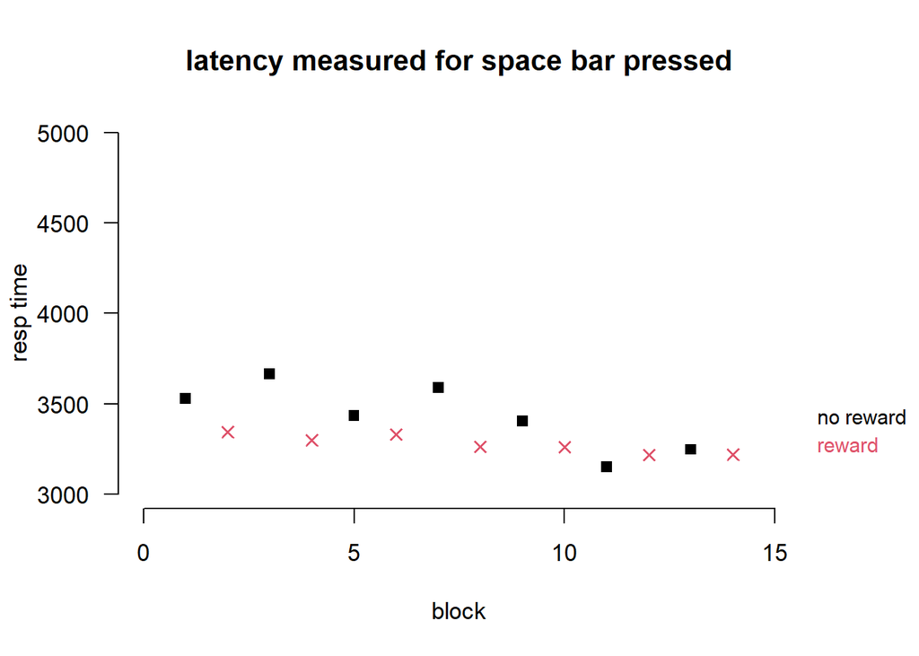

```r
#split dataset based on response-space
space.dat <- subset(dat.cor, response_space == "space")
no_space.dat <- subset(dat.cor, response_space == "None")

x<- ddply(space.dat, c("condition", "response_space", 'block'),
             summarise,
            latency = mean(response_time_space))

y<- ddply(no_space.dat, c("condition", "response_space", 'block'),
             summarise,
            latency = mean(response_time_space))

#Plot for response-space set to space
# increase labels and left margin:
par(cex=1.1, mar=c(5.1,4.1,4.1,4.1))
# setup empty plot with simplified axes:
emptyPlot(c(0,15), c(3000,5000), # x-range, y-range plot
          main="latency measured for space bar pressed", # title
          xlab="block", ylab="resp time", # labels axes
           las=1) # simplify y-axis

# add averages:
points(x$block, x$latency, lwd=1.5,
       pch=ifelse(x$condition=="no_reward", 15,4),
       bg='white',
       col=ifelse(x$condition=="no_reward", 1,2 ))

# add legend:
leg <- tapply(x$latency, list(x$condition), mean)
text(c(16,16), leg,  labels=gsub("_", " ", names(leg)),
     adj=0, col=ifelse(names(leg)=="no_reward", 1,2), cex=.85, xpd=TRUE)
```

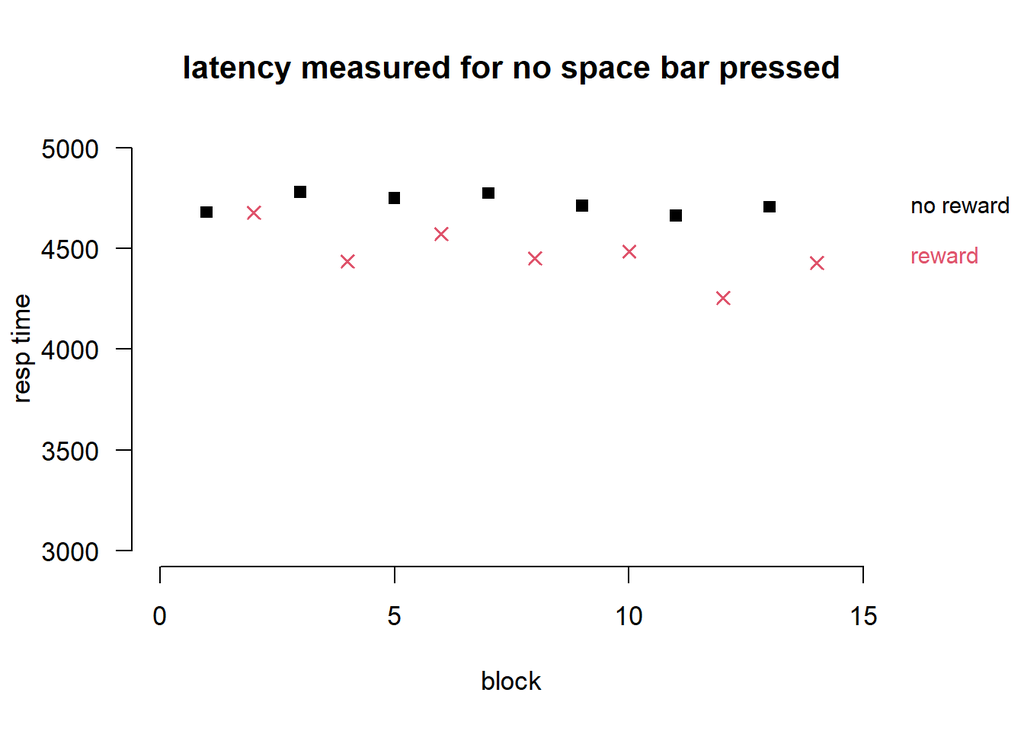

```r
#Plot for response-space set to none
# increase labels and left margin:
par(cex=1.1, mar=c(5.1,4.1,4.1,4.1))
# setup empty plot with simplified axes:
emptyPlot(c(0,15), c(3000,5000), # x-range, y-range plot
          main="latency measured for no space bar pressed", # title
          xlab="block", ylab="resp time", # labels axes
           las=1) # simplify y-axis

# add averages:
points(y$block, y$latency, lwd=1.5,
       pch=ifelse(y$condition=="no_reward", 15,4),
       bg='white',
       col=ifelse(y$condition=="no_reward", 1,2 ))

# add legend:
leg <- tapply(y$latency, list(y$condition), mean)
text(c(16,16), leg,  labels=gsub("_", " ", names(leg)),
     adj=0, col=ifelse(names(leg)=="no_reward", 1,2), cex=.85, xpd=TRUE)
```

## Q2a

**Plot the distribution of the reaction times using a QQ-plot (functions qqnorm and qqline). Include the plot and the code in your report.**

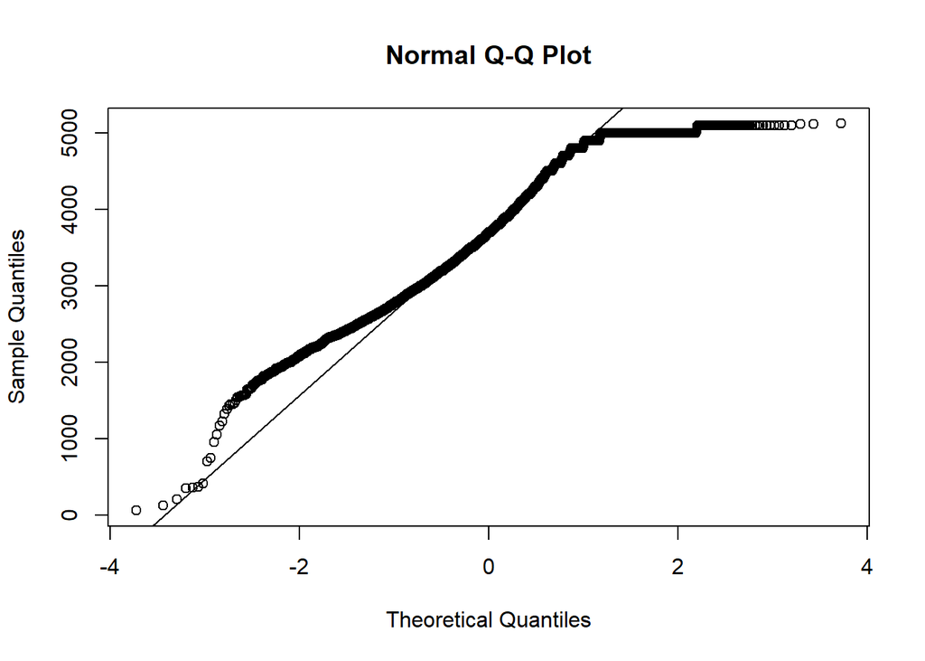

```r
qqnorm(dat.cor$response_time_space)
qqline(dat.cor$response_time_space)
```

**Are the reaction times following a normal distribution? Describe how you can see in the QQ-plot whether the reaction times follow a normal distribution.**

The reaction time does not follow a strict normal distribution. It is skewed on both the tail ends. The initial observations that cluster close to around 0ms have higher values which can be attributed to the fact that reaction times cannot be zero. Furthermore, the qqplot shows variance with respect to the normal distribution from around 1000ms-2500ms where there are higher number of observations. Around the range of 3000-4000ms, the reaction times seem to follow a normal distribution. Finally, the skewness at the right tail of the distribution (at around 4500ms-5000ms) indicates that there are more observations at this interval. Overall, the data does not follow a normal distribution and this can be seen evidently around 2000-2500ms and around 4000ms-5000ms. This can be due to the fact that the multiple categorical variables(condition, response_space) having very different distributions.

## Q2b

**Inspect the reaction times. Include the code in your report.**

```r
#inspecting reaction time based on block
summary(avg_latency_block$latency)
```

```
##    Min. 1st Qu.  Median    Mean 3rd Qu.    Max.
##    3476    3556    3679    3742    3921    4106
```

```r
table(avg_latency_block$latency, avg_latency_block$block)
```

```
##
##                    1 2 3 4 5 6 7 8 9 10 11 12 13 14
##   3475.99076212471 0 0 0 0 0 0 0 0 0  0  0  1  0  0
##   3512.67832167832 0 0 0 0 0 0 0 0 0  0  0  0  0  1
##   3531.57106598985 0 0 0 1 0 0 0 0 0  0  0  0  0  0
##   3551.05910165485 0 0 0 0 0 0 0 0 0  1  0  0  0  0
##   3569.73903002309 0 0 0 0 0 0 0 1 0  0  0  0  0  0
##   3649.13272311213 0 0 0 0 0 1 0 0 0  0  0  0  0  0
##   3651.39256198347 0 0 0 0 0 0 0 0 0  0  0  0  1  0
##   3705.86857142857 0 1 0 0 0 0 0 0 0  0  0  0  0  0
##   3709.72786885246 0 0 0 0 0 0 0 0 0  0  1  0  0  0
##   3897.84638554217 0 0 0 0 1 0 0 0 0  0  0  0  0  0
##   3929.10810810811 0 0 0 0 0 0 0 0 1  0  0  0  0  0
##   4042.05705705706 0 0 0 0 0 0 1 0 0  0  0  0  0  0
##   4059.85014409222 1 0 0 0 0 0 0 0 0  0  0  0  0  0
##   4105.88719512195 0 0 1 0 0 0 0 0 0  0  0  0  0  0
```

```r
#inspecting reaction time based on response_space
summary(no_space.dat$response_time_space)
```

```
##    Min. 1st Qu.  Median    Mean 3rd Qu.    Max.
##    2400    4500    4800    4609    5000    5122
```

```r
summary(space.dat$response_time_space)
```

```
##    Min. 1st Qu.  Median    Mean 3rd Qu.    Max.
##      57    2824    3317    3336    3858    5090
```

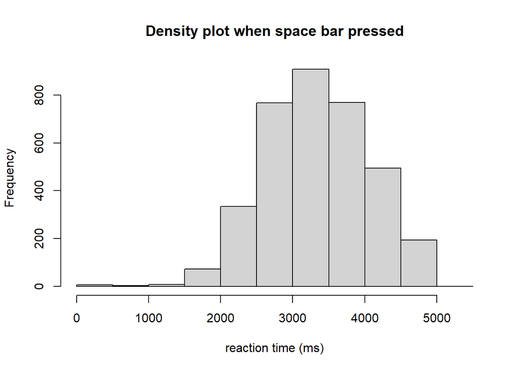

```r
hist(space.dat$response_time_space, xlab = 'reaction time (ms)', main = 'Density plot when space bar pressed')
```

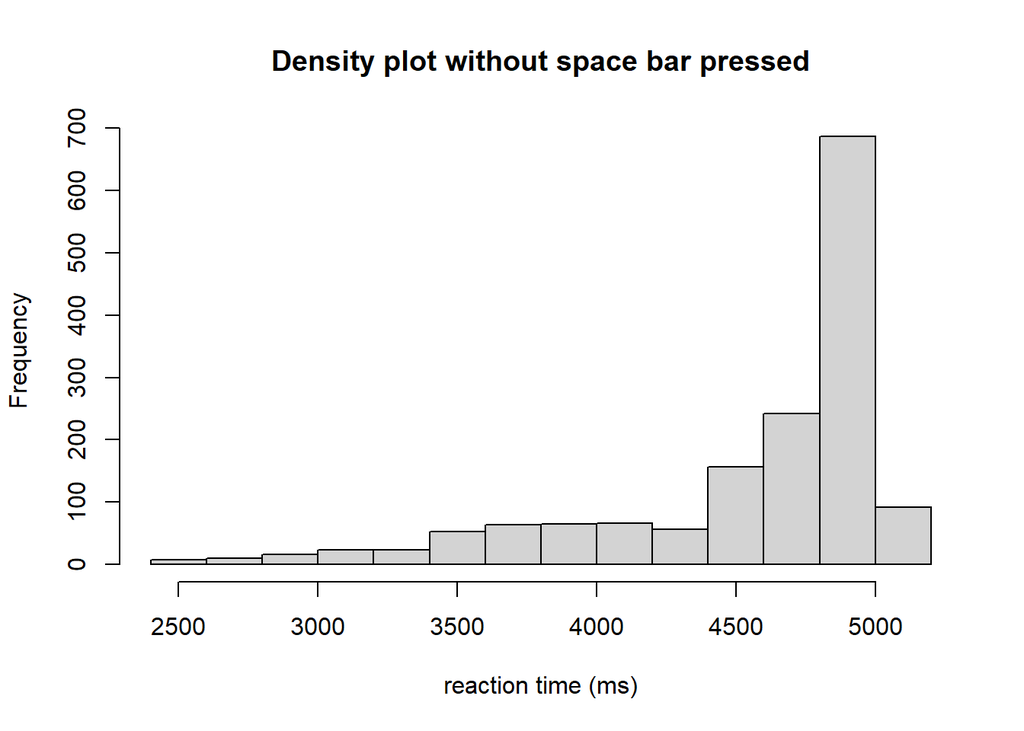

```r
hist(no_space.dat$response_time_space, xlab = 'reaction time (ms)', main = 'Density plot without space bar pressed')
```

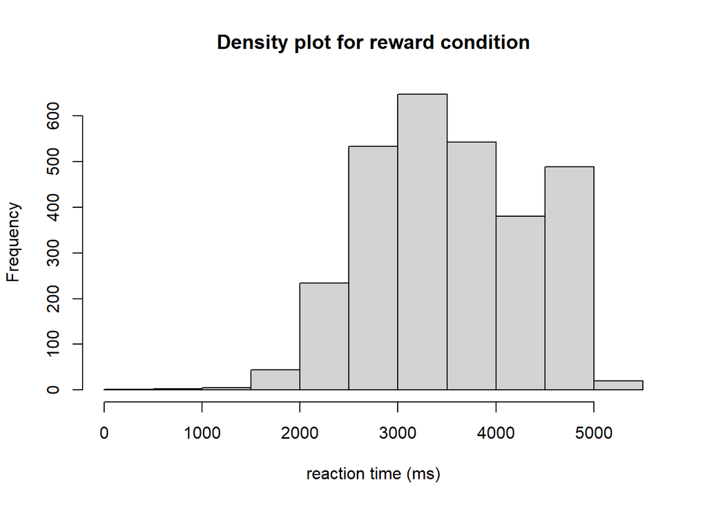

```r
#inspecting reaction time based on condition
hist(reward.dat$response_time_space, xlab = 'reaction time (ms)', main = 'Density plot for reward condition')
```

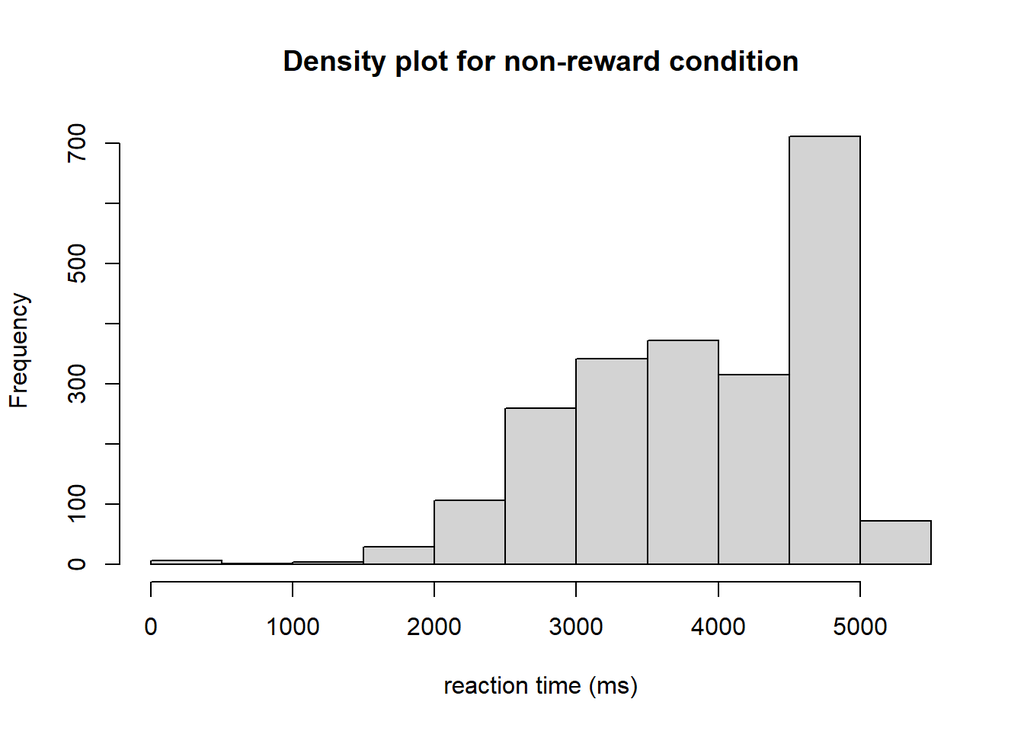

```r
hist(no_reward.dat$response_time_space, xlab = 'reaction time (ms)', main = 'Density plot for non-reward condition')
```

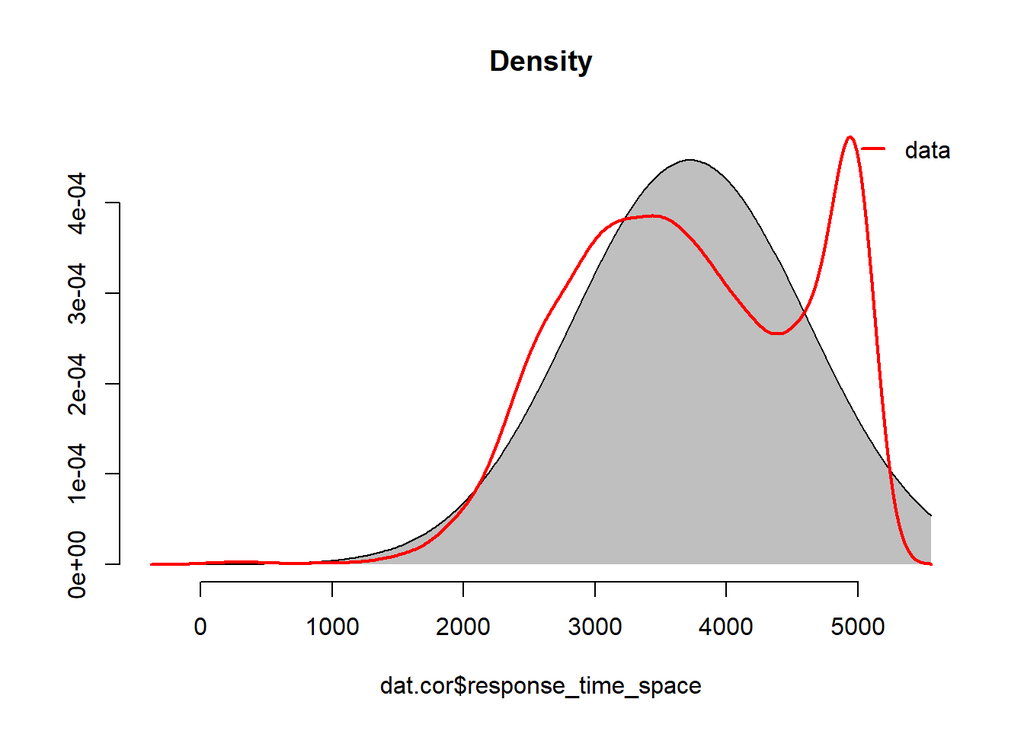

```r
#check distribution of reaction times with respect to normal distribution
check_normaldist(dat.cor$response_time_space, xlab = 'reaction time (ms)')
```

**Are there obvious outliers (i.e., values that are clearly problematic)? Explain why you think these points are outliers. If there are any clear outliers, remove these from the data. Include the code in your report.**

The maximum reaction time can not cross beyond 5000ms because even if the subjects did not press the space bar, the maximum time until the input prompt occurred is 5000ms. Therefore, any reaction time beyond 5000ms is a wrong value and can be removed.

```r
exclude <- c(5001:6000)

library(dplyr)
dat.cor <- dat.cor %>%
  filter(!(dat.cor$response_time_space %in% exclude))

summary(dat.cor$response_time_space)
```

```
##    Min. 1st Qu.  Median    Mean 3rd Qu.    Max.
##      57    3019    3663    3699    4500    5000
```

**Name a characteristic of this set of reaction times that make it difficult to transform the data so that it approximates a normal distribution. (Hint: Plot a histogram if you cannot see it in the QQ plot.)**

The response times vary with respect to the conditions. The distribution of the reaction times has different means in different condition blocks. Therefore, it is difficult to fit a normal distribution to the data which has two means.

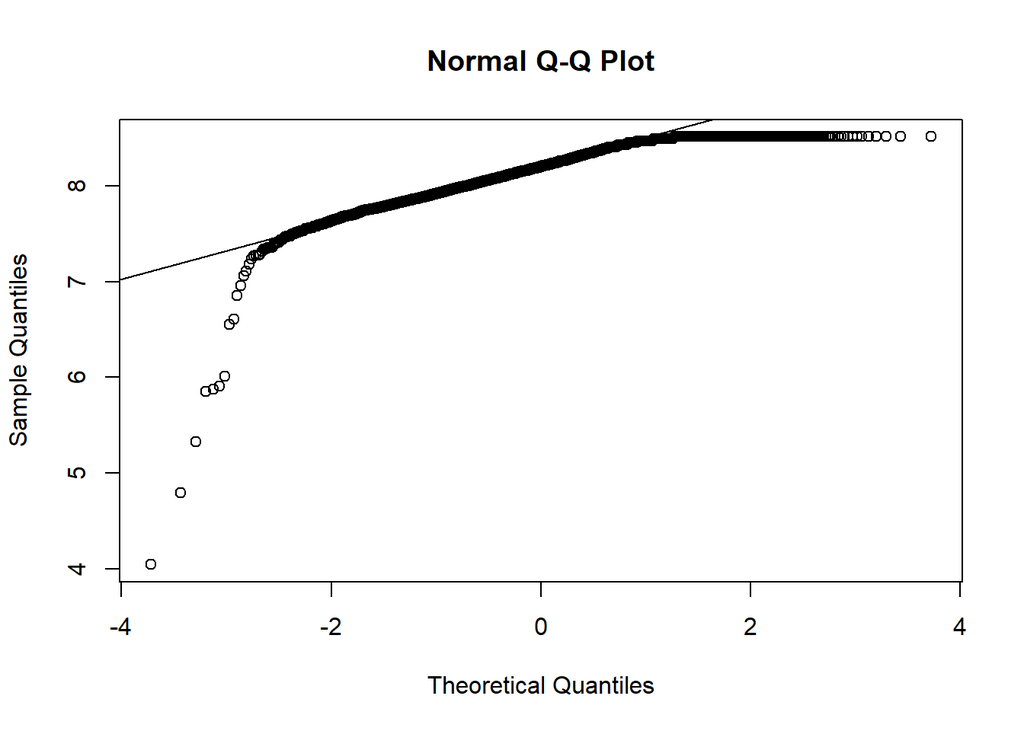

```r
dat.cor$logRT <- log(dat.cor$response_time_space)
qqnorm(dat.cor$logRT)
qqline(dat.cor$logRT)
```

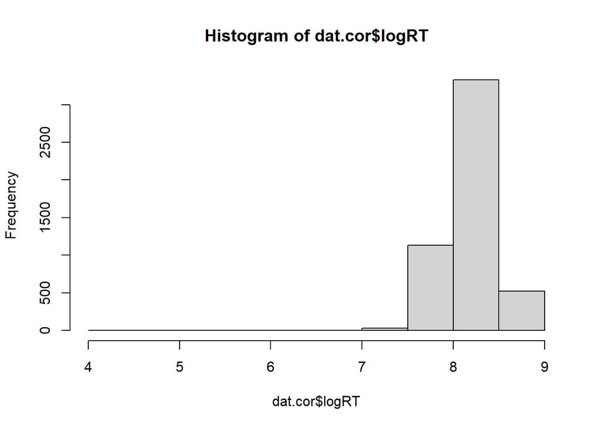

```r
hist(dat.cor$logRT)
```

## Q3a

```r
m1 <- lm(response_time_space ~ block*condition*response_space, data=dat.cor)
summary(m1)
```

```
##
## Call:
## lm(formula = response_time_space ~ block * condition * response_space,
##     data = dat.cor)
##
## Residuals:
##     Min      1Q  Median      3Q     Max
## -3304.4  -436.5    82.1   415.6  1756.5
##
## Coefficients:
##                                            Estimate Std. Error t value Pr(>|t|)
## (Intercept)                                4741.550     44.496 106.561  < 2e-16
## block                                        -8.408      6.157  -1.366 0.172146
## conditionreward                            -115.652     73.510  -1.573 0.115716
## response_spacespace                       -1067.769     57.505 -18.568  < 2e-16
## block:conditionreward                       -12.358      8.881  -1.392 0.164125
## block:response_spacespace                   -26.305      7.682  -3.424 0.000622
## conditionreward:response_spacespace        -196.295     88.414  -2.220 0.026451
## block:conditionreward:response_spacespace    36.329     10.635   3.416 0.000640
##
## (Intercept)                               ***
## block
## conditionreward
## response_spacespace                       ***
## block:conditionreward
## block:response_spacespace                 ***
## conditionreward:response_spacespace       *
## block:conditionreward:response_spacespace ***
## ---
## Signif. codes:  0 '***' 0.001 '**' 0.01 '*' 0.05 '.' 0.1 ' ' 1
##
## Residual standard error: 663.8 on 5018 degrees of freedom
## Multiple R-squared:  0.4323, Adjusted R-squared:  0.4315
## F-statistic: 545.9 on 7 and 5018 DF,  p-value: < 2.2e-16
```

```r
#dat.corr <- as.factor(dat.cor$block)
```

**Answer the following questions: - What is represented by the intercept? - What does the estimate block represent? What can you conclude from it’s value in the summary? - What does the estimate response_spacespace represent? What can you conclude from it’s value in the summary? - What does the estimate block:conditionreward represent? What can you conclude from it’s value in the summary? (Hint: for this question you can ignore the other interactions, and just focus on this estimate.)**

The estimate block:conditionreward has a value of approximately -12.358 which represents a drop in reaction time for reward condition block in contrast to non-reward condition.

## Q3b

**Use a QQ-plot to visualize the distribution of the residuals of the model. Hint: you can extract the residuals from the model using resid(m1)**

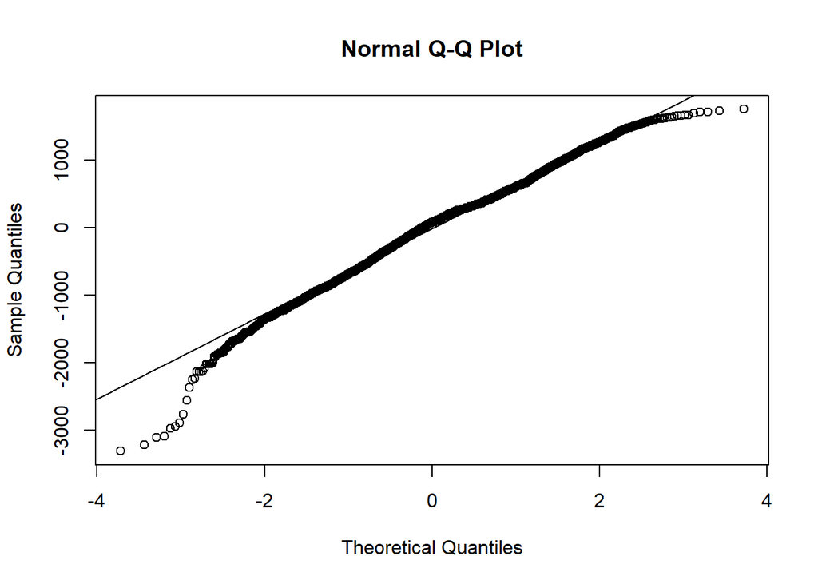

```r
residuals<-resid(m1)
qqnorm(residuals)
qqline(residuals)
```

**Compare the QQ-plot of the residuals with a QQ-plot of the input data (i.e., the dependent variable, the un-transformed reaction times; see Question 2a). The distribution of the residuals looks much closer to the normal distribution than the original data. Why do the residuals show a different pattern than the data?**

The residuals can follow a normal distribution even if the data is not normally distributed. The residuals may show a different pattern because they are not influenced by the data showing non-normal distribution. In the qqplot of the residuals, the distribution on the right tail end (with larger values) is less skewed in comparison to the qqplot of the data (q:2a). This is due to the outliers (observations with reaction times greater than 5000ms) that were removed. However, unlike the distribution of the data, which had two intervals (around 2000ms and 4000ms) that heavily varied from the normal distribution, the residuals seem to be relatively normally distributed in the center. This can be due to the fact that the data distribution varies significantly between different conditions (reward and non-reward) but the residuals of these observations followed a normal distribution.

## 4a

**What are the fitted effects of a statistical model? (they can be extracted using fitted, but also with predict)**

Fitted effects are the fitted values or predicted values that you get when you substitute the levels/categories/co-efficient associated with the predictor variables into the model.

```r
# create a new data file:
newd <- expand.grid(block = 1:14,
                    condition = c("reward", "no_reward"),
                    response_space=c("space", "None"),
                    stringsAsFactors = FALSE)

# generate predictions (fitted values) for each condition:
fv <- predict(m1, newd, se.fit=TRUE)
newd$fit <- fv$fit
newd$se  <- fv$se.fit

head(newd)
```

```
##   block condition response_space      fit       se
## 1     1    reward          space 3351.091 29.73249
## 2     2    reward          space 3340.349 26.60582
## 3     3    reward          space 3329.607 23.62121
## 4     4    reward          space 3318.865 20.83981
## 5     5    reward          space 3308.123 18.35421
## 6     6    reward          space 3297.381 16.30031
```

```r
#fitted values
val<-fitted(m1)
summary(val)
```

```
##    Min. 1st Qu.  Median    Mean 3rd Qu.    Max.
##    3211    3276    3340    3699    4408    4733
```

**Plot the model estimates of newd. Include the code and the plot in your report.**

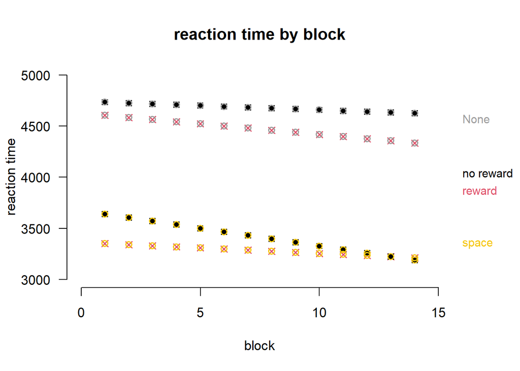

```r
library(plotfunctions)

# increase labels and left margin:
par(cex=1.1, mar=c(5.1,4.1,4.1,4.1))
# setup empty plot with simplified axes:
emptyPlot(c(0,15), c(3000,5000), # x-range, y-range plot
          main="reaction time by block", # title
          xlab="block", ylab="reaction time", # labels axes
           las=1) # simplify y-axis

# add averages:
points(newd$block, newd$fit, lwd=1.5,
       pch=ifelse(newd$condition=="no_reward", 15,4),
       bg='white',
       col=ifelse(newd$condition=="no_reward", 1,2 ),
       )
points(newd$block, newd$fit, lwd=1.5,
       col= ifelse(newd$response_space=="space", 7,8 ))

# add legend:
leg1 <- tapply(newd$fit, list(newd$condition), mean)
text(c(16,16), leg1,  labels=gsub("_", " ", names(leg1)),
     adj=0, col=ifelse(names(leg1)=="no_reward", 1,2), cex=.85, xpd=TRUE)

leg2 <- tapply(newd$fit, list(newd$response_space), mean)
text(c(16,16), leg2,  labels=gsub("_", " ", names(leg2)),
     adj=0, col=ifelse(names(leg2)=="space", 7,8), cex=.85, xpd=TRUE)
```

## 4b

**Based on the plots, explain which predictor has the largest influence on the participants’ reaction times.**

The reaction times vary most significantly based on the response_space condition. For observations that pressed the space bar, the reaction times are around 3500ms. Whereas, for no space bar pressed, the reaction times are higher at around 4500ms. This is clearly evident in the plot. It can also be noted that in general, the reward block has lower reaction times than the non-reward block for both space bar pressed and no space bar.